# Fitting growth models using predmicror

Vasco Cadavez

Ursula Gonzales Barron

2022/04/30

In this tutorial we will explain how to fit primary growth models to experimental data. For this lab, we will use the `predmicror` R package developed to accommodate all the functions we are being using in predictive microbiology workshops. The `predmicror` package is outside the base R functions, and the first step is load the `predmicror`, package with the principal predictive microbial growth models, and `gslnls` which is a package to fit non-linear models using non-linear least squares.

```r
library(predmicror)
library(gslnls)
library(ggplot2)
```

## 0.1 Loading data

To conduct statistical analyses, we need to import data into R working environment. The `predmicror` package has incorporated datasets, and we can use the `data()` function to load the example datasets to the working environment. Thus, we will start by fitting a full growth model to experimental data, thus we load the `growthfull.Rda` dataset which is part of the `predmicror` package.

```r
data(growthfull)
```

```r
growthfull
```

```
##    Time    logN     lnN
## 1     0 -0.1046 -0.2006
## 2     2  0.0792  0.1922
## 3     4  0.1212  0.1587
## 4     6  0.7344  1.5290
## 5     8  2.5531  5.9421
## 6    10  3.8358  8.8024
## 7    12  5.8476 13.3749
## 8    14  7.1938 16.1457
## 9    16  8.7521 20.2299
## 10   18  9.1119 20.8575
## 11   20  9.3162 21.6272
## 12   22  9.2224 20.5114
## 13   24  9.3019 21.3943
```

```r
head(growthfull)
```

```
##   Time    logN     lnN
## 1    0 -0.1046 -0.2006
## 2    2  0.0792  0.1922
## 3    4  0.1212  0.1587
## 4    6  0.7344  1.5290
## 5    8  2.5531  5.9421
## 6   10  3.8358  8.8024
```

For data outer to `predmicror`package, usually in .csv format, which are flat text files we use the `read.csv()` function to import the CSV file into R environment. Before load a dataset, its good practice to assure that the dataset is located in the working directory, thus to import a CSV file called `growthfull.csv` into the R environment we do it with the next code section.

```r
growthfull <- read.csv("growthfull.csv", sep = ";", header = TRUE)
```

We have the dataset in the R environment, thus we can start checking the data proprieties. For example, the `str()` function gives information considering the structure of the variables (numeric, integer, etc.), and the `names()` function show us the variables names.

```r
str(growthfull)
```

```
## 'data.frame':    13 obs. of  3 variables:
##  $ Time: int  0 2 4 6 8 10 12 14 16 18 ...
##  $ logN: num  -0.1046 0.0792 0.1212 0.7344 2.5531 ...
##  $ lnN : num  -0.201 0.192 0.159 1.529 5.942 ...
```

```r
names(growthfull)
```

```
## [1] "Time" "logN" "lnN"
```

## 0.2 Plotting data

To check the relationship between `Time` and `lnN`, we might use the function `plot()`, and we can check the data by visual inspection.

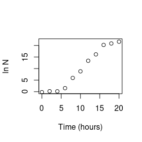

```r
plot(lnN ~ Time,
  data = growthfull,
  xlab = "Time (hours)", ylab = "ln N",
  xlim = c(0, 20), ylim = c(0, 22)
)
```

To save the plot as an `.png` object, we can use the `png()` function.

```r
png("growthfull.png")
plot(lnN ~ Time,
  data = growthfull,
  xlab = "Time (hours)", ylab = "ln N",
  xlim = c(0, 20), ylim = c(0, 22)
)
dev.off()
```

## 0.3 Fitting the Huang full model

```r
start_values <- list(Y0 = 0.02, Ymax = 22, MUmax = 1.6, lag = 5)
```

Now we can fit the model to the data `growthfull`:

```r
fit <- gsl_nls(lnN ~ HuangFM(Time, Y0, Ymax, MUmax, lag),
  data = growthfull,
  start = start_values
)
```

Next, we can check the model parameters:

```r
summary(fit)
```

```
##
## Formula: lnN ~ HuangFM(Time, Y0, Ymax, MUmax, lag)
##
## Parameters:
##       Estimate Std. Error t value Pr(>|t|)
## Y0     0.04562    0.25768   0.177    0.863
## Ymax  21.13232    0.22393  94.372 8.54e-15 ***
## MUmax  1.85942    0.06076  30.601 2.08e-10 ***
## lag    5.07987    0.25000  20.320 7.89e-09 ***
## ---
## Signif. codes:  0 '***' 0.001 '**' 0.01 '*' 0.05 '.' 0.1 ' ' 1
##
## Residual standard error: 0.4444 on 9 degrees of freedom
##
## Number of iterations to convergence: 6
## Achieved convergence tolerance: 7.528e-12
```

```r
coef(fit)
```

```
##          Y0        Ymax       MUmax         lag
##  0.04562352 21.13231521  1.85942430  5.07986541
```

The `predict()` function from the `gslnls` package can be used to produce both confidence and prediction intervals for the prediction of `lnN` for a given `Time`.

```r
newTimes <- data.frame(Time = seq(0, 24, by = 0.1))
fits <- data.frame(predict(fit, newdata = newTimes, interval = "confidence", level = 0.95))
str(fits)
```

```
## 'data.frame':    241 obs. of  3 variables:
##  $ fit: num  0.0456 0.0456 0.0456 0.0456 0.0456 ...
##  $ lwr: num  -0.0986 -0.0986 -0.0986 -0.0986 -0.0986 ...
##  $ upr: num  0.19 0.19 0.19 0.19 0.19 ...
```

```r
preds <- data.frame(predict(fit, newdata = newTimes, interval = "prediction", level = 0.95))
str(preds)
```

```
## 'data.frame':    241 obs. of  3 variables:
##  $ fit: num  0.0456 0.0456 0.0456 0.0456 0.0456 ...
##  $ lwr: num  -0.97 -0.97 -0.97 -0.97 -0.97 ...
##  $ upr: num  1.06 1.06 1.06 1.06 1.06 ...
```

Plot the observed data with the fitted values and confidence interval

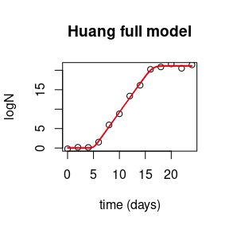

```r
plot(newTimes$Time, fits$fit,
  type = "l", col = "blue",
  xlab = "time (days)", ylab = "logN",
  main = "Huang full model"
)
points(growthfull$Time, growthfull$lnN)
lines(newTimes$Time, fits$upr, col = "red")
lines(newTimes$Time, fits$lwr, col = "red")
```

Plot the observed data with the fitted values and prediction interval

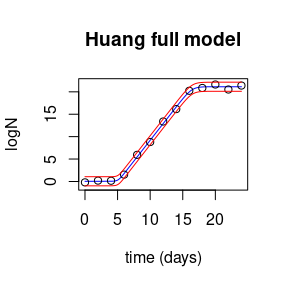

```r
plot(newTimes$Time, fits$fit,
  type = "l", col = "blue",
  xlab = "time (days)", ylab = "logN", ylim = c(-1, 22), xlim = c(0, 24),
  main = "Huang full model"
)
points(growthfull$Time, growthfull$lnN)
lines(newTimes$Time, preds$upr, col = "red")
lines(newTimes$Time, preds$lwr, col = "red")
```

## 0.4 Fitting the Fang no lag model

First, we want to load the data set:

```r
data(growthnolag)
growthnolag
```

```
##    Time   logN     lnN
## 1     0 0.7344  1.5290
## 2     2 2.5531  5.9421
## 3     4 3.8358  8.8024
## 4     6 5.8476 13.3749
## 5     8 7.1938 16.1457
## 6    10 8.7521 20.2299
## 7    12 9.1119 20.8575
## 8    14 9.3162 21.6272
## 9    16 9.2224 20.5114
## 10   18 9.3019 21.3943
```

Let’s start with the Fang model, fit the model to the experimental data using nonlinear least squares function `gsl_nls()` implemented in the `gsl_nls` R package:

```r
start_values <- list(Y0 = 0.01, Ymax = 22, MUmax = 1.6)
fit <- gsl_nls(lnN ~ FangNLM(Time, Y0, Ymax, MUmax),
  data = growthnolag,
  start = start_values
)
fit
```

```
## Nonlinear regression model
##   model: lnN ~ FangNLM(Time, Y0, Ymax, MUmax)
##    data: growthnolag
##     Y0   Ymax  MUmax
##  1.758 21.132  1.859
##  residual sum-of-squares: 1.678
##
## Algorithm: multifit/levenberg-marquardt, (scaling: more, solver: qr)
##
## Number of iterations to convergence: 5
## Achieved convergence tolerance: 1.394e-11
```

Next, we can check the model parameters:

```r
summary(fit)
```

```
##
## Formula: lnN ~ FangNLM(Time, Y0, Ymax, MUmax)
##
## Parameters:
##       Estimate Std. Error t value Pr(>|t|)
## Y0     1.75827    0.36368   4.835  0.00189 **
## Ymax  21.13234    0.24673  85.650 7.79e-12 ***
## MUmax  1.85922    0.06619  28.091 1.86e-08 ***
## ---
## Signif. codes:  0 '***' 0.001 '**' 0.01 '*' 0.05 '.' 0.1 ' ' 1
##
## Residual standard error: 0.4896 on 7 degrees of freedom
##
## Number of iterations to convergence: 5
## Achieved convergence tolerance: 1.394e-11
```

Next, we can extract the model parameters and apply the model to new data

```r
newTimes <- data.frame(Time = seq(0, 18, by = 0.1))
fits <- data.frame(predict(fit, newdata = newTimes, interval = "confidence", level = 0.95))
str(fits)
```

```
## 'data.frame':    181 obs. of  3 variables:
##  $ fit: num  1.76 1.94 2.13 2.32 2.5 ...
##  $ lwr: num  1.53 1.72 1.91 2.1 2.29 ...
##  $ upr: num  1.99 2.17 2.35 2.53 2.72 ...
```

```r
preds <- data.frame(predict(fit, newdata = newTimes, interval = "prediction", level = 0.95))
```

Plot the observed data with the fitted values and confidence interval

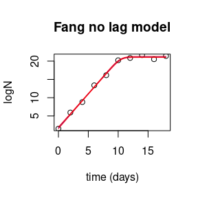

```r
plot(newTimes$Time, fits$fit,
  type = "l", col = "blue",
  xlab = "time (days)", ylab = "logN",
  main = "Fang no lag model"
)
points(growthnolag$Time, growthnolag$lnN)
lines(newTimes$Time, fits$upr, col = "red")
lines(newTimes$Time, fits$lwr, col = "red")
```

Plot the observed data with the fitted values and prediction interval

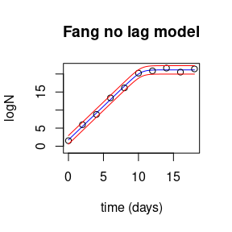

```r
plot(newTimes$Time, fits$fit,
  type = "l", col = "blue",
  xlab = "time (days)", ylab = "logN", ylim = c(-1, 22), xlim = c(0, 18),
  main = "Fang no lag model"
)
points(growthnolag$Time, growthnolag$lnN)
lines(newTimes$Time, preds$upr, col = "red")
lines(newTimes$Time, preds$lwr, col = "red")
```

## 0.5 Fitting the Buchanan reduced model

First, we want to load the data set:

```r
data(growthred)
growthred
```

```
##   Time    logN     lnN
## 1    0 -0.1046 -0.2006
## 2    2  0.0792  0.1922
## 3    4  0.1212  0.1587
## 4    6  0.7344  1.5290
## 5    8  2.5531  5.9421
## 6   10  3.8358  8.8024
## 7   12  5.8476 13.3749
## 8   14  7.1938 16.1457
## 9   16  8.7521 20.2299
```

Let’s start with the Buchanan model, fit the model to the experimental data using nonlinear least squares function `gsl_nls()` implemented in the `gslnls` R package:

```r
start_values <- list(Y0 = 0.01, MUmax = 1.6, lag = 5)
fit <- gsl_nls(lnN ~ BuchananRM(Time, Y0, MUmax, lag),
  data = growthred,
  start = start_values
)
```

Next, we can check the model parameters:

```r
summary(fit)
```

```
##
## Formula: lnN ~ BuchananRM(Time, Y0, MUmax, lag)
##
## Parameters:
##       Estimate Std. Error t value Pr(>|t|)
## Y0     0.05010    0.22810    0.22    0.833
## MUmax  1.83840    0.04722   38.93 1.92e-08 ***
## lag    5.04160    0.21567   23.38 4.02e-07 ***
## ---
## Signif. codes:  0 '***' 0.001 '**' 0.01 '*' 0.05 '.' 0.1 ' ' 1
##
## Residual standard error: 0.3951 on 6 degrees of freedom
##
## Number of iterations to convergence: 3
## Achieved convergence tolerance: 5.878e-11
```

Next, we can extract the model parameters and apply the model to new data

```r
newTimes <- data.frame(Time = seq(0, 16, by = 0.1))
fits <- data.frame(predict(fit, newdata = newTimes, interval = "confidence", level = 0.95))
str(fits)
```

```
## 'data.frame':    161 obs. of  3 variables:
##  $ fit: num  0.0501 0.0501 0.0501 0.0501 0.0501 ...
##  $ lwr: num  -0.0853 -0.0853 -0.0853 -0.0853 -0.0853 ...
##  $ upr: num  0.185 0.185 0.185 0.185 0.185 ...
```

```r
preds <- data.frame(predict(fit, newdata = newTimes, interval = "prediction", level = 0.95))
```

Plot the observed data with the fitted values and confidence interval

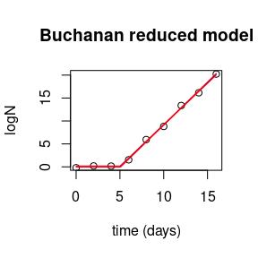

```r
plot(newTimes$Time, fits$fit,
  type = "l", col = "blue",
  xlab = "time (days)", ylab = "logN",
  main = "Buchanan reduced model"
)
points(growthred$Time, growthred$lnN)
lines(newTimes$Time, fits$upr, col = "red")
lines(newTimes$Time, fits$lwr, col = "red")
```

Plot the observed data with the fitted values and prediction interval

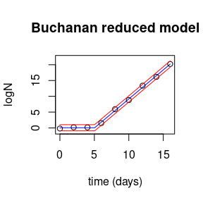

```r
plot(newTimes$Time, fits$fit,
  type = "l", col = "blue",
  xlab = "time (days)", ylab = "logN", ylim = c(-1, 22), xlim = c(0, 16),
  main = "Buchanan reduced model"
)
points(growthred$Time, growthred$lnN)
lines(newTimes$Time, preds$upr, col = "red")
lines(newTimes$Time, preds$lwr, col = "red")
```